# 統計学2

$t$ 分布と母平均の推定

矢内 勇生

2018-05-18（改訂: 2018-05-21; 2019-05-14; 2019-05-29; 2019-05-30, 2020-08-29, 2021-05-27）

## 準備

必要なパッケージを読み込み、図の日本語が正しく表示されるようにする。

```r
library(tidyverse)

if (.Platform$OS.type == "windows") {
  if (require(fontregisterer)) {
    my_font <- "Yu Gothic"
  } else {
    my_font <- "Japan1"
  }
} else if (capabilities("aqua")) {
  my_font <- "HiraginoSans-W3"
} else {
  my_font <- "IPAexGothic"
}

theme_set(theme_gray(base_size   = 9,
                     base_family = my_font))
```

## 母集団を定義する

成人男性の身長に興味があるとする。母集団の人口を100万、母平均を約170cm、母標準偏差を約6cm に設定する。

```r
pop <- rnorm(1e6, mean = 170, sd = 6)
```

母集団の身長分布は以下のようになる。

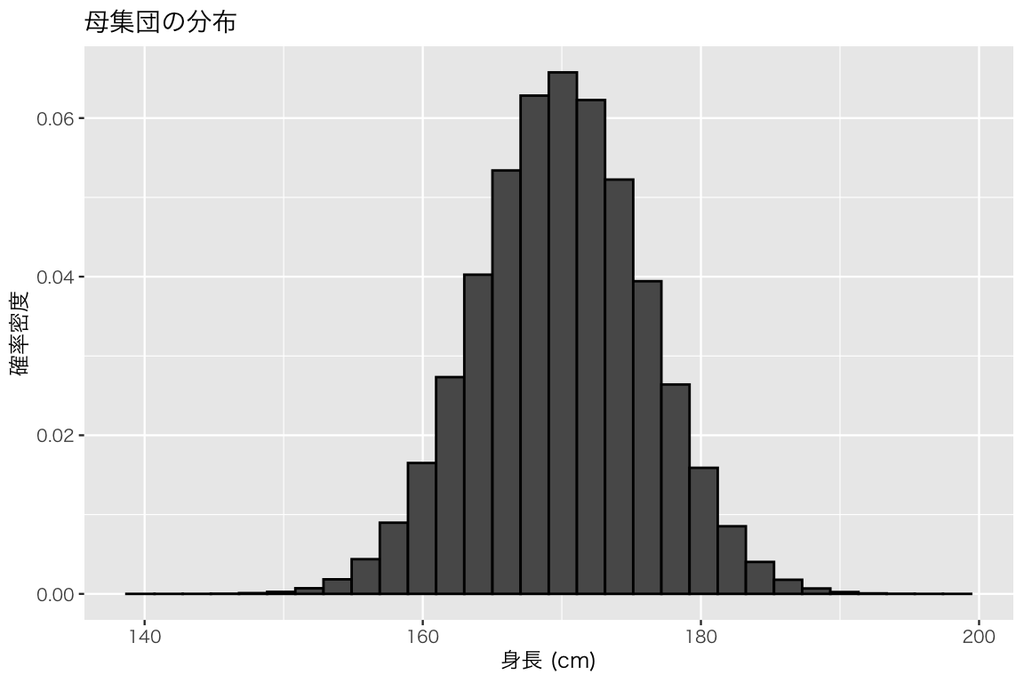

```r
pop_height <- ggplot(tibble(pop),
                     aes(x = pop,
                         y = after_stat(density))) +
  geom_histogram(color = "black") +
  labs(x = "身長 (cm)",
       y = "確率密度",
       title = "母集団の分布")
plot(pop_height)
```

実際の母平均は、

```r
mean(pop)
```

```
## [1] 169.9955
```

であり、母標準偏差は、

```r
sd(pop)
```

```
## [1] 6.011032
```

である。

## 標本を抽出して母平均を推定する

### 標本抽出と母平均の推定のシミュレーション

100万人の母集団で全員を調べるのではなく、10人だけ標本として抜き出して母平均を推定することを考える。 シミュレーションで標本抽出を1万回繰り返し、それぞれの標本で標本平均を計算しよう。

まず、標本サイズを10に、シミュレーション回数を1万に設定する。

```r
N <- 10          # 標本サイズ
n_sims <- 1e4    # シミュレーションの繰り返し回数
```

1万個の標本平均を保存するためのベクトルを用意する。

```r
means <- rep(NA, 1e4)
```

また、後で使うので、不偏分散の平方根も保存できるようにする。

```r
u <- rep(NA, 1e4)
```

母集団 `pop` から標本サイズ `N = 10` の標本を抽出する作業を `n_sims` = 10^{4} 回繰り返し、それぞれで標本平均と不偏分散の平方根を計算する。

```r
for (i in 1:n_sims) {
  smpl <- sample(pop, size = N, replace = FALSE)
  means[i] <- mean(smpl)
  u[i] <- sd(smpl)
}
```

標本平均の標本分布を確認してみよう。

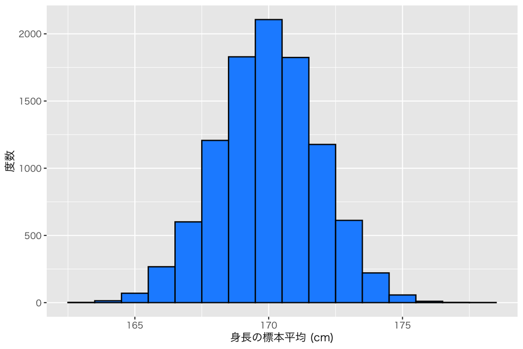

```r
df_sim <- tibble(mean = means,
                 sd = u)
h1 <- ggplot(df_sim, aes(x = mean)) +
  geom_histogram(binwidth = 1,
                 color = "black",
                 fill = "dodgerblue") +
  labs(x = "身長の標本平均 (cm)",
       y = "度数")
plot(h1)
```

なんとなく正規分布になっているように見えるが、果たしてそうだろうか。 得られた標本平均を標準化して、標準正規分布と分布を比べてみよう。

#### **母分散 $\sigma^2$ を知っているとき**

母分散 $\sigma^2$（あるいは母標準偏差 $\sigma$）を知っているという特殊な場合について考える。このとき、標本平均 $\bar{x}$は、以下の式で標準化 (standardize) できる。
$$z = \frac{\bar{x} - \mu}{\frac{\sigma}{\sqrt{N}}}.$$
標本平均は不偏推定量なので、
$$\mathbb{E}[\bar{x}] = \mu$$
となる。そこで、$\mu$ は、

```r
(mu <- mean(means))
```

```
## [1] 169.9729
```

としよう。

また、仮定により $\sigma$ は知っているので母集団の $\sigma$ を使う。

```r
(sigma <- sd(pop))
```

```
## [1] 6.011032
```

これらの値を使うと、標準化された標本平均 $z$ は、

```r
z <- (means - mu) / (sigma / sqrt(N))
```

となる。

この $z$ の分布を確認してみよう。

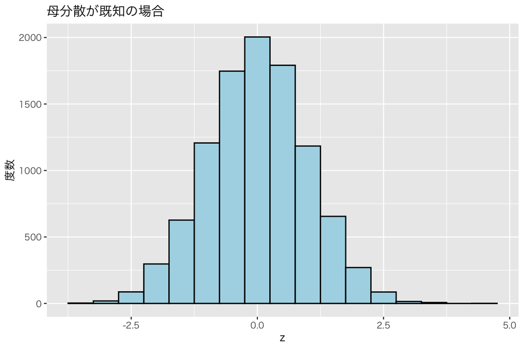

```r
df_sim$z <- z
h2 <- ggplot(df_sim, aes(x = z)) +
  geom_histogram(binwidth = 0.5,
                 color = "black",
                 fill = "lightblue") +
  labs(title = "母分散が既知の場合",
       y = "度数")
plot(h2)
```

標準正規分布に似ているように見える。`geom_density()` を使って $z$ の確率密度曲線（青い点線） を描き、標準正規分布の確率密度曲線（赤い実線）と比べてみよう。

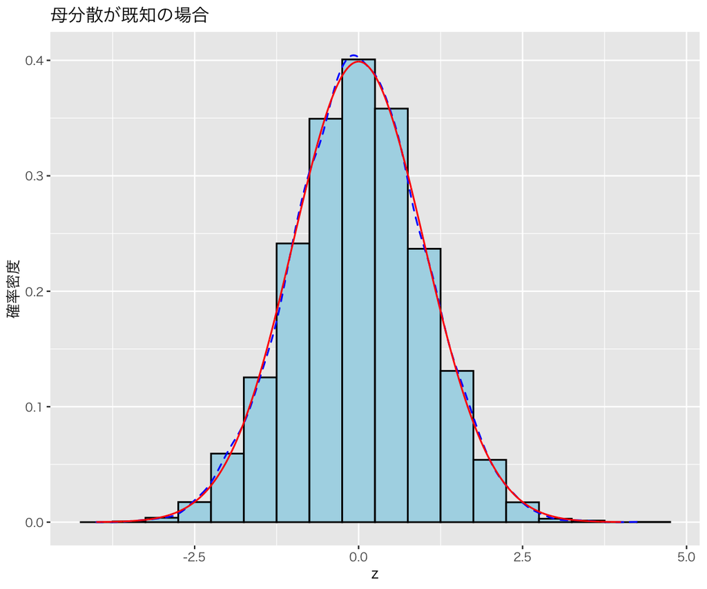

```r
df_sim$x <- seq(from = -4, to = 4, length.out = nrow(df_sim))
df_sim$dens <- dnorm(df_sim$x, mean = 0, sd = 1)
h3 <- ggplot(df_sim) +
  geom_histogram(aes(x = z, y = after_stat(density)),
                 binwidth = 0.5,
                 color = "black",
                 fill = "lightblue") +
  geom_density(aes(x = z, y = after_stat(density)),
               color = "blue",
               linetype = "dashed") +
  geom_line(aes(x = x, y = dens),
            color = "red") +
  labs(y = "確率密度",
       title = "母分散が既知の場合")
plot(h3)
```

2つの確率密度曲線はほぼ一致している。

この例のように、母分散を知っているとき、標本平均を標準化した $z$ の分布は標準正規分布に従う。したがって、私たちは区間推定に標準正規分布を利用することができる。

#### **母分散 $\sigma^2$ を知らないとき**

しかし、通常私たちは標本しか調べられないので母分散を知らない。母分散を知らないときはどうなるだろうか。

母分散を知らないとき、先ほどと同じ標準化はできない。なぜなら、上で使った標準化の式には、$\sigma$ が出てくるが、その値を知らないからだ。そこで、母標準偏差 $\sigma$ の推定値として、不偏分散の平方根 $u$ を使う。この値は既に`u`として保存してある。

この $u$ を使い、標本平均 $\bar{x}$は、以下の式で標準化する（$\hat{z}$ は「$z$ハット」と読む）。
$$\hat{z} = \frac{\bar{x} - \mu}{\frac{u}{\sqrt{N}}}.$$

```r
z_hat <- (means - mu) / (u / sqrt(N))
```

この $\hat{z}$ の分布を確認してみよう。

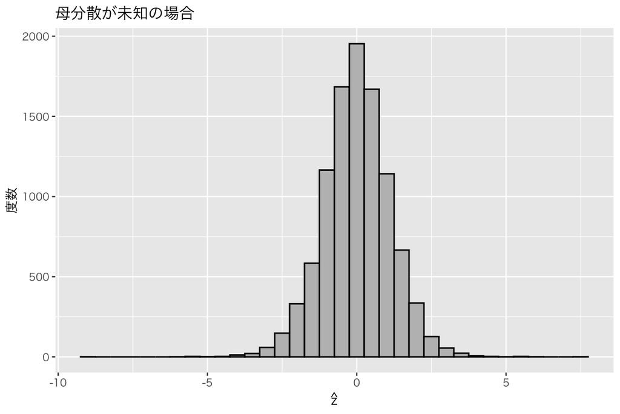

```r
df_sim$z_hat <- z_hat
h4 <- ggplot(df_sim, aes(x = z_hat)) +
  geom_histogram(binwidth = 0.5,
                 color = "black",
                 fill = "gray") +
  labs(x = expression(hat(z)),
       y = "度数",
       title = "母分散が未知の場合")
plot(h4)
```

標準正規分布に似ているように見えるが、どうだろうか。`geom_density()` を使って $\hat{z}$の確率密度曲線（青い点線） を描き、標準正規分布の確率密度曲線（赤い実線）と比べてみよう。

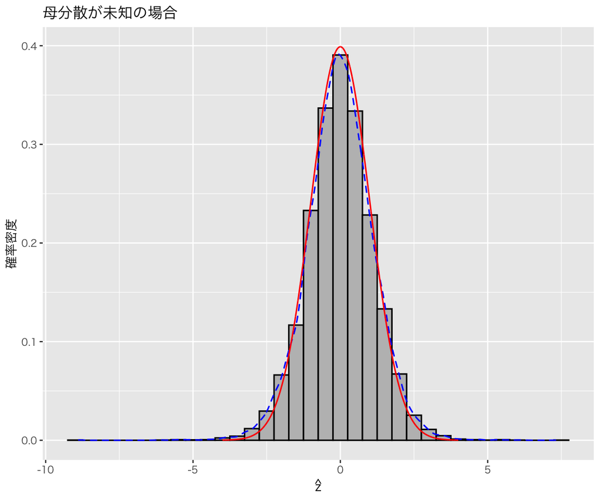

```r
h5 <- ggplot(df_sim) +
  geom_histogram(aes(x = z_hat, y = after_stat(density)),
                 binwidth = 0.5,
                 color = "black",
                 fill = "gray") +
  geom_density(aes(x = z_hat, y = after_stat(density)),
               color = "blue",
               linetype = "dashed") +
  geom_line(aes(x = x, y = dens),
            color = "red") +
  labs(x = expression(hat(z)),
       y = "確率密度",
       title = "母分散が未知の場合")
plot(h5)
```

2つの確率密度曲線は、少しずれている。 2つの確率密度は、0（付近）で最大値をとるという点で同じである。 しかし、分布のばらつきが違う。 平均値付近を比べると、$\hat{z}$ の分布の方が確率密度が低くなっている。 代わりに、分布の両裾を比べると、$\hat{z}$ の分布の方が、確率密度が高い。 言い換えると、$\hat{z}$ の分布は、標準正規分布よりも裾が厚い（重い）分布になっている。

この例のように、母分散を知らないとき、標本平均を標準化した $\hat{z}$ の分布は**標準正規分布に従わない**。したがって、私たちは区間推定に標準正規分布を利用することが**できない**。

実は、$\hat{z}$ の分布は自由度 $N - 1$ の $t$ 分布にしたがっている。 ためしに（シミュレーションで使ったサンプル$N$は 10なので）自由度9の$t$分布の確率密度曲線（赤い実線）を重ね書きしてみよう。

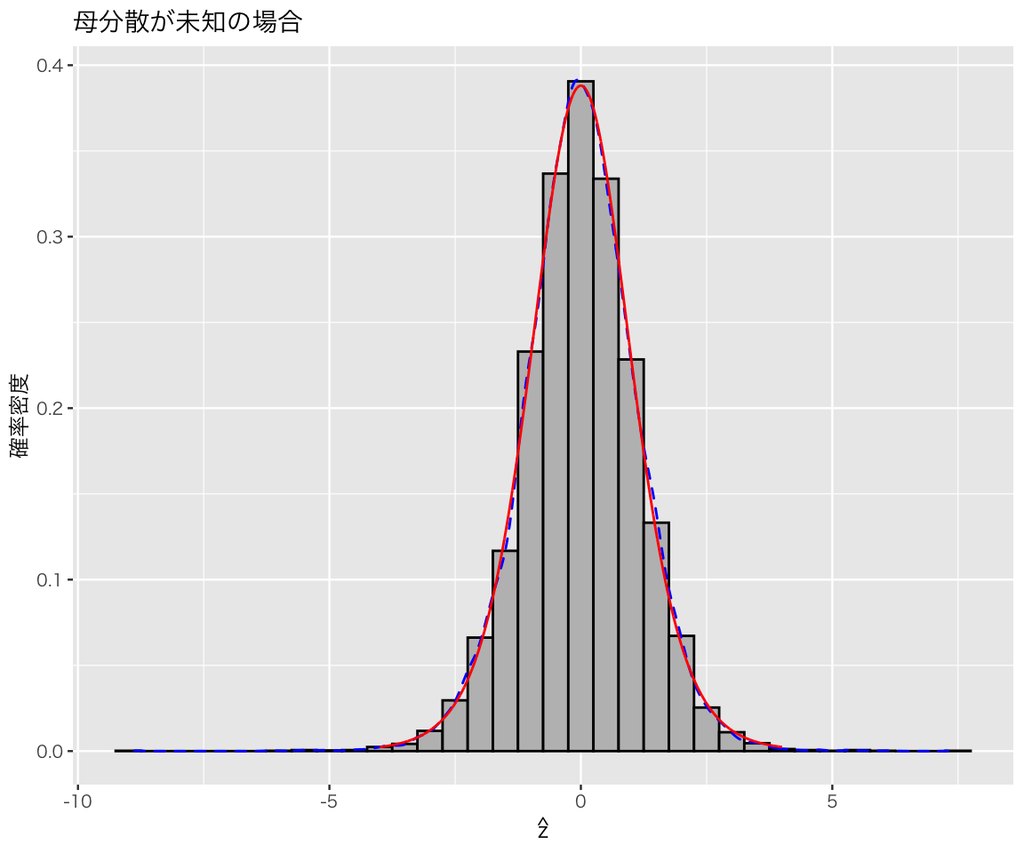

```r
df_sim$tdens <- dt(df_sim$x, df = 9)
h6 <- ggplot(df_sim) +
  geom_histogram(aes(x = z_hat, y = after_stat(density)),
                 binwidth = 0.5,
                 color = "black",
                 fill = "gray") +
  geom_density(aes(x = z_hat, y = after_stat(density)),
               color = "blue",
               linetype = "dashed") +
  geom_line(aes(x = x, y = tdens),
            color = "red") +
  labs(x = expression(hat(z)),
       y = "確率密度",
       title = "母分散が未知の場合")
plot(h6)
```

このように、確率密度曲線がほぼ一致する。

#### $\ast$分布の比べ方

上の例では、確率密度曲線を重ね書きすることで分布を比較した。 もう少し厳密に分布を比べたいとき、特に2つの分布が同じ分布といえるかどうか確かめたいときには、Q-Qプロット (qunatile-quantile plot) という図を使う。

この図では、分布を確かめる対象となるシミュレーションで得た変数の分位点 (quantile) を縦軸に、比較対象の分布の分位点を横軸にとる。分位点と分位点を比べるので、Q-Q プロットと呼ばれる。

分位点とは、簡単に言うと、「確率分布で下からa%分に相当する値はいくつか」という値である。標準正規分布では、2.5%の分位点 (「2.5パーセンタイル」と呼ばれる) は$-1.96$、50%の分位点（50パーセンタイル）は0、97.5％の分位点は1.96 である。 Rでは、`quantile()` で分位点を求めることができる。

```r
quantile(z, probs = c(0.025, 0.5, 0.975))
```

```
##         2.5%          50%        97.5%
## -1.968565253 -0.001995798  1.922012245
```

シミュレーションで得た $z$ の分布については、2.5パーセンタイルが -1.97、50パーセンタイルが0、97.5パーセンタイルが 1.92 であることがわかる。

2つの分布がもし完全に一致するなら、2つの分布の a% の分位点は、aがどんな値であっても等しいはずである。したがって、片方の分布の分位点を $y$、もう一方の分布の分位点を $x$ とすれば、2つの分布が等しいときには $y=x$ になるはずである。つまり、yとxの散布図の点が45度線の上にすべて乘るはずである。

この性質を利用し、Q-Qプロット上の点が45度線の上にあるかどうか（45度線からどれだけずれているか）を調べることで、分布を比較してみよう。

まず、$z$（母分散を知っているときに、標本平均を標準化したもの; sample）と標準正規分布 (`qnorm`) を比べてみよう。 標準正規分布と比較するためのQ-Qプロットは、`stat_qq()` で作れる。

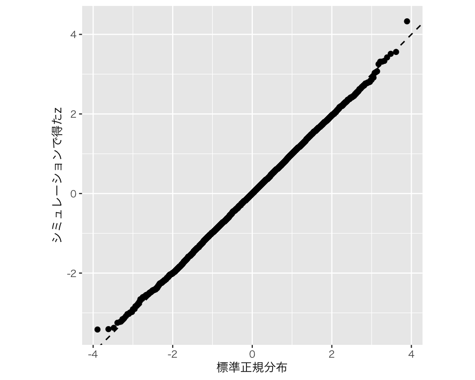

```r
qq1 <- ggplot(df_sim, aes(sample = z)) +
  geom_abline(intercept = 0,
              slope = 1,
              linetype = "dashed") +  # 45度線
  stat_qq(distribution = qnorm) +
  coord_fixed(ratio = 1) +       　   # 図の縦横比を1:1にする
  labs(x = "標準正規分布",
       y = "シミュレーションで得たz")
plot(qq1)
```

シミュレーションなので多少のずれはあるものの、点がほぼ45度線上にあることがわかる。

次に、$\hat{z}$（母分散を知らないときに、標本平均を標準化したもの）と標準正規分布を比べてみよう。

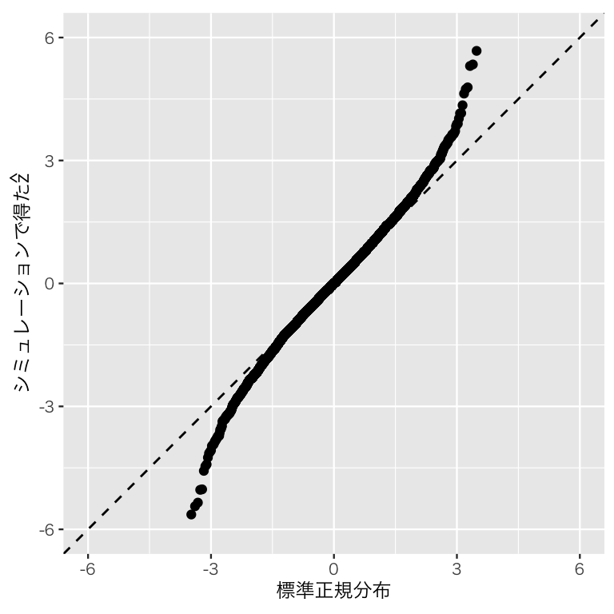

```r
qq2 <- ggplot(df_sim, aes(sample = z_hat)) +
  geom_abline(intercept = 0,
              slope = 1,
              linetype = "dashed") +  # 45度線
  stat_qq(distribution = qnorm) +
  xlim(-6, 6) + ylim(-6, 6) +
  coord_fixed(ratio = 1) +            # 図の縦横比を1:1にする
  labs(x = "標準正規分布",
       y = expression(paste("シミュレーションで得た", hat(z))))
plot(qq2)
```

先ほどとは異なり、点が45度線から大きくずれている。ここから、$\hat{z}$は標準正規分布に従わないことがよりはっきりとわかる。特に、裾（図の両端）で標準正規分布との違いが大きいことがわかるだろう。

最後に、$\hat{z}$（母分散を知らないときに、標本平均を標準化したもの）と自由度9の$t$分布 (`qt(df = 9)`) を比べてみよう。

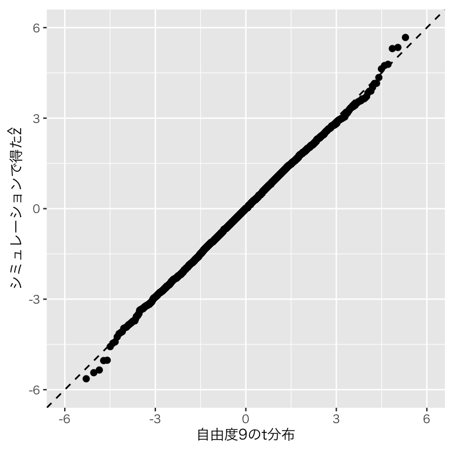

```r
qq3 <- ggplot(df_sim, aes(sample = z_hat)) +
  geom_abline(intercept = 0,
              slope = 1,
              linetype = "dashed") +  # 45度線
  stat_qq(distribution = qt, dparams = 9) +
  xlim(-6, 6) + ylim(-6, 6) +
  coord_fixed(ratio = 1) +            # 図の縦横比を1:1にする
  labs(x = "自由度9のt分布",
       y = expression(paste("シミュレーションで得た", hat(z))))
plot(qq3)
```

やはり多少のずれはあるものの、ほとんどの点が45度線上に乗っていることがわかる。よって、$\hat{z}$は、自由度9の$t$分布に従っていると言えそうである（少なくとも、「自由度9の$t$分布に従っていない」とはっきり言うことはできない）。

### $t$ 分布を理解する

$t$ 分布は、自由度 $df > 0$ によってその形を変える。

たとえば、自由度1, 2, 10の $t$乗分布は以下のように分布する。比較のため、標準正規分布も一緒に示す。

まず、データフレームを作る。

```r
x1 <-  seq(-3, 3, length = 1000)
stdn <- dnorm(x1, mean = 0, sd = 1)
t1 <- dt(x1, df = 1)
t2 <- dt(x1, df = 2)
t10 <- dt(x1, df = 10)
df_t <- tibble(x = rep(x1, 4),
               t = c(stdn, t1, t2, t10),
               group = rep(c("stdn", "t1", "t2", "t10"), rep(1000, 4)))
glimpse(df_t)
```

```
## Rows: 4,000
## Columns: 3
## $ x     <dbl> -3.000000, -2.993994, -2.987988, -2.981982, -2.975976, -2.969970…
## $ t     <dbl> 0.004431848, 0.004512344, 0.004594136, 0.004677241, 0.004761679,…
## $ group <chr> "stdn", "stdn", "stdn", "stdn", "stdn", "stdn", "stdn", "stdn", …
```

図を作る（この図の作り方は理解できなくてもよい）。

[figure not shown]

```r
plt_t <- ggplot(df_t, aes(x = x, y = t,
                          color = group, linetype = group)) +
  geom_line() +
  scale_color_brewer(palette = "Accent",
                     name = "",
                     labels = c("標準正規分布", "t(df = 1)",
                                "t(df = 2)", "t(df = 10)")) +
  scale_linetype_discrete(name = "",
                          labels = c("標準正規分布", "t(df = 1)",
                                     "t(df = 2)", "t(df = 10)")) +
  labs(x = "", y = "確率密度")
plot(plt_t)
```

$t$分布の特徴として、

- 0を中心として左右対称
- 標準正規分布より山が低く、裾が厚い（重い）
- 自由度が大きくなるほど標準正規分布に近づく

という点が挙げられらる。

$t$分布の形状を確認するための関数を用意したので、これを使って色々な$t$分布の形状を確認し、$t$分布の特徴を理解しよう（この関数の中身を理解する必要はない）。

```r
plot_t <- function(df) {
  x <- seq(from = -4, to = 4, length = 1000)
  t <- dt(x, df = df)
  nml <- dnorm(x, mean = 0, sd = 1)
  d <- tibble(x, t, nml)
  p <- ggplot(d, aes(x = x)) +
    geom_line(aes(y = nml), linetype = "dashed") +
    geom_line(aes(y = t), color = "royalblue") +
    labs(x = "", y = "確率密度",
         title = str_c("自由度", df, "のt分布（青い実線）と標準正規分布（黒い点線）"))
  plot(p)
}
```

自由度1の$t$分布は、

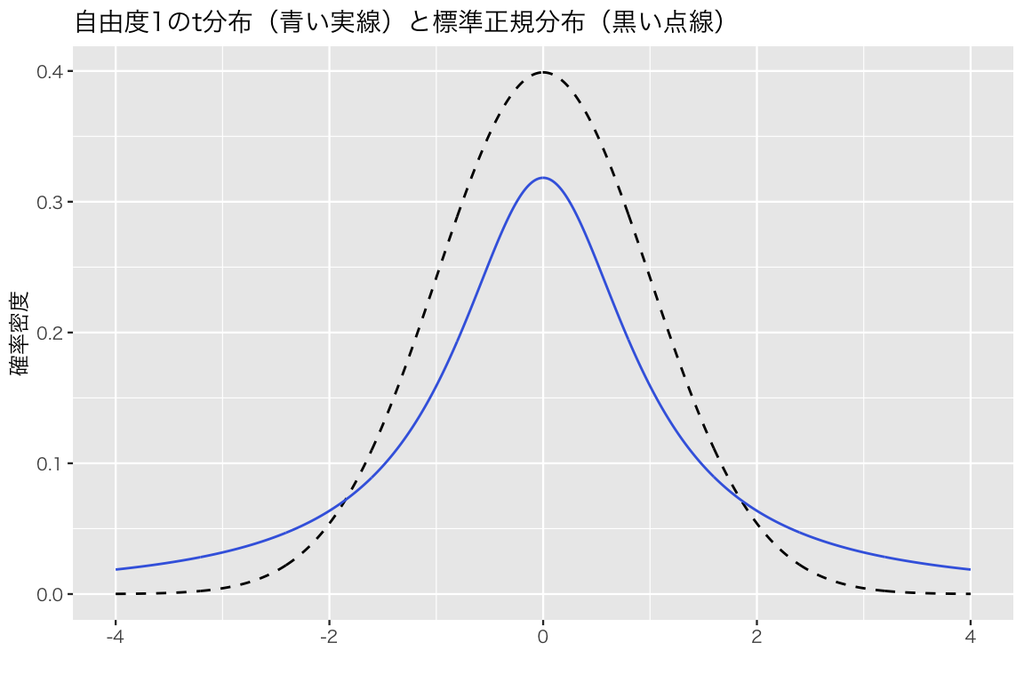

```r
plot_t(df = 1)
```

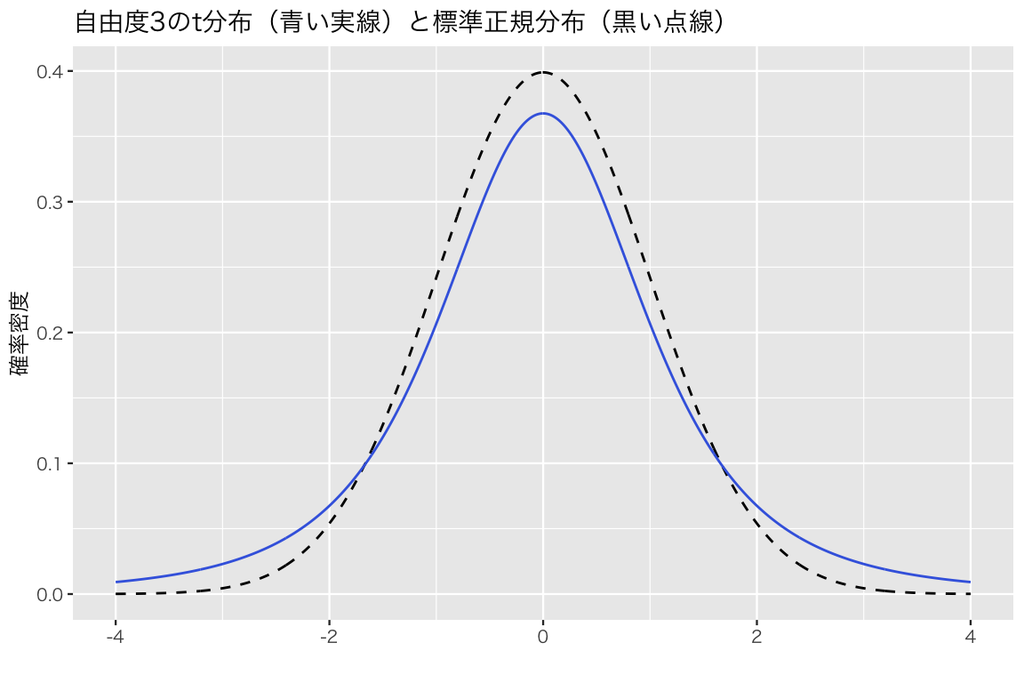

```r
plot_t(df = 3)
```

**実習課題：**

自由度 (df) の値をによって$t$分布がどのように変化するか、関数 `plot_t()` を使って確かめてみよう。

### $t$ 分布を利用した区間推定

$t$ 分布を使った区間推定の方法も、基本的に標準正規分布を使った推定方法と同じである。 身長 $x$ の点推定値を $\bar{x}$ とすると、以下のように定義される信頼区間 (confidence interval) を区間推定に使う。
$$\left[\bar{h} - t_{N-1, p} \cdot \mathrm{SE}, \bar{h} + t_{N-1, p} \cdot \mathrm{SE} \right].$$

標準正規分布で $Q$ と表していた値（`qnorm()` で求めた）を$t_{N-1, p}$ （`qt()` で求める）に変えただけである。

母集団から $N=10$ の標本を1つ取り出して、身長の母平均を推定してみよう。

```r
smpl_1 <- sample(pop, size = 10, replace = FALSE)
```

身長 $x$ の母平均の点推定値 $\bar{x}$ は、

```r
(x_bar <- mean(smpl_1))
```

```
## [1] 167.7088
```

である。

また、標準誤差（の推定値）は、
$$\widehat{\mathrm{SE}} = \frac{u}{\sqrt{N}}$$
だから、

```r
(se <- sd(smpl_1) / sqrt(10))
```

```
## [1] 2.283386
```

である。

ここで、標本サイズ$N = 10$ だから、区間推定を行うには自由度 $N - 1 = 9$ の $t$ 分布を利用する。95パーセント信頼区間を求めたいとすると、$t$分布の下側2.5%分と、上側2.5%分を除外したい。そのために必要なのが、$t_{9, 0.025}$（または、$-t_{9, 0.025}$）の値である。これを `qt()` で求める。

```r
qt(df = 9, p = 0.025)  # 下側
```

```
## [1] -2.262157
```

```r
## qt(df = 9, p = 0.025, lower.tail = FALSE)  # 上側
## qt(df = 9, p = 0.975)  # 上側はこれでも求められる
```

これらの値を使うと、母平均の95%信頼区間を求める。

```r
(lb <- x_bar + qt(df = 9, p = 0.025) * se)
```

```
## [1] 162.5434
```

```r
(ub <- x_bar + qt(df = 9, p = 0.975) * se)
```

```
## [1] 172.8742
```

よって、母平均の95%信頼区間は、[162.54, 172.87] である。

ちなみに、$t$ 分布の代わりに標準正規分布を使って95%信頼区間を求めると、

```r
(lb_n <- x_bar + qnorm(p = 0.025) * se)
```

```
## [1] 163.2335
```

```r
(ub_n <- x_bar + qnorm(p = 0.975) * se)
```

```
## [1] 172.1842
```

となり、[163.23, 172.18] という区間が得られる。この区間は、$t$分布を使って求めた区間よりも短い。 つまり、標準正規分布を使うと、不確実性を低く見積もり、「自信過剰な」信頼区間を出してしまう。結果として、標本抽出を繰り返しても**95%信頼区間が正解を出す確率が95%よりも低くなってしまう**ので注意が必要である。

最後に、$t$ 分布を使って区間推定を行う関数を作っておこう。

```r
get_ci <- function(x, level = 0.95) {
  ## t 分布を利用して母平均の95%信頼区間を求める関数
  ## 引数：x = 標本（観測値のベクトル）
  ##       level = 信頼度（既定値は0.95）
  N <- length(x)  # 標本サイズを調べる
  x_bar <- mean(x)
  se <- sd(x) / sqrt(N)
  t <- qt(df = N - 1, p = (1 - level) / 2, lower.tail = FALSE)
  lb <- x_bar - t * se
  ub <- x_bar + t * se
  confint <- c(下限値 = lb, 上限値 = ub)
  message(paste0(level * 100, "%信頼区間"))
  return(confint)
}
```

この関数を使ってみよう。標本1 (smpl_1) から得られる母平均の95%信頼区間は、

```r
get_ci(smpl_1)
```

```
## 95%信頼区間
```

```
##   下限値   上限値
## 162.5434 172.8742
```

となり、先ほどと同じ結果が得られた。

89%信頼区間は、

```r
get_ci(smpl_1, level = 0.89)
```

```
## 89%信頼区間
```

```
##   下限値   上限値
## 163.6606 171.7571
```

である。

99.9%信頼区間は、

```r
get_ci(smpl_1, level = 0.999)
```

```
## 99.9%信頼区間
```

```
##   下限値   上限値
## 156.7921 178.6255
```

である。

授業の内容に戻る